# HW2.Q3.Ko

## 3

```r
nfl <- read.table('nfl.txt', header = TRUE)
head(nfl)
```

```
##    y   x1   x2   x3   x4 x5  x6   x7   x8   x9
## 1 10 2113 1985 38.9 64.7  4 868 59.7 2205 1917
## 2 11 2003 2855 38.8 61.3  3 615 55.0 2096 1575
## 3 11 2957 1737 40.1 60.0 14 914 65.6 1847 2175
## 4 13 2285 2905 41.6 45.3 -4 957 61.4 1903 2476
## 5 10 2971 1666 39.2 53.8 15 836 66.1 1457 1866
## 6 11 2309 2927 39.7 74.1  8 786 61.0 1848 2339
```

```r
result <- lm(y ~ ., data = nfl)
summary(result)
```

```
##
## Call:
## lm(formula = y ~ ., data = nfl)
##
## Residuals:
##     Min      1Q  Median      3Q     Max
## -3.0408 -0.6802 -0.1131  0.9835  2.9785
##
## Coefficients:
##               Estimate Std. Error t value Pr(>|t|)
## (Intercept) -7.292e+00  1.281e+01  -0.569 0.576312
## x1           8.124e-04  2.006e-03   0.405 0.690329
## x2           3.631e-03  8.410e-04   4.318 0.000414 ***
## x3           1.222e-01  2.590e-01   0.472 0.642750
## x4           3.189e-02  4.160e-02   0.767 0.453289
## x5           1.511e-05  4.684e-02   0.000 0.999746
## x6           1.590e-03  3.248e-03   0.490 0.630338
## x7           1.544e-01  1.521e-01   1.015 0.323547
## x8          -3.895e-03  2.052e-03  -1.898 0.073793 .
## x9          -1.791e-03  1.417e-03  -1.264 0.222490
## ---
## Signif. codes:  0 '***' 0.001 '**' 0.01 '*' 0.05 '.' 0.1 ' ' 1
##
## Residual standard error: 1.83 on 18 degrees of freedom
## Multiple R-squared:  0.8156, Adjusted R-squared:  0.7234
## F-statistic: 8.846 on 9 and 18 DF,  p-value: 5.303e-05
```

**(b)** When a team's rushing percent increases by 1, then their number of games won will increase by 0.1543533 when all of the remaining regressor variables constant.

```r
partial_result <- lm(y ~ x2+x7+x8, data = nfl)
newdata <- data.frame(x2 = 2000, x7 = 48, x8 = 2350)
predict(partial_result, newdata, level=0.95, interval="prediction")
```

```
##        fit        lwr      upr
## 1 3.381448 -0.5163727 7.279268
```

**(d)** $H_0: \beta_1 = \beta_2 = ... = \beta_9 = 0$, $H_a: $ at least one of the $\beta_j \neq 0, for j = 1, ..., 9$

- F statistic: 8.85
- p-value: 0.000053

Therefore, with small p-value, we can reject the null hypothesis and conclude that our model is useful.

```r
p <- 10
n <- nrow(nfl)

summary(result)
```

```
##
## Call:
## lm(formula = y ~ ., data = nfl)
##
## Residuals:
##     Min      1Q  Median      3Q     Max
## -3.0408 -0.6802 -0.1131  0.9835  2.9785
##
## Coefficients:
##               Estimate Std. Error t value Pr(>|t|)
## (Intercept) -7.292e+00  1.281e+01  -0.569 0.576312
## x1           8.124e-04  2.006e-03   0.405 0.690329
## x2           3.631e-03  8.410e-04   4.318 0.000414 ***
## x3           1.222e-01  2.590e-01   0.472 0.642750
## x4           3.189e-02  4.160e-02   0.767 0.453289
## x5           1.511e-05  4.684e-02   0.000 0.999746
## x6           1.590e-03  3.248e-03   0.490 0.630338
## x7           1.544e-01  1.521e-01   1.015 0.323547
## x8          -3.895e-03  2.052e-03  -1.898 0.073793 .
## x9          -1.791e-03  1.417e-03  -1.264 0.222490
## ---
## Signif. codes:  0 '***' 0.001 '**' 0.01 '*' 0.05 '.' 0.1 ' ' 1
##
## Residual standard error: 1.83 on 18 degrees of freedom
## Multiple R-squared:  0.8156, Adjusted R-squared:  0.7234
## F-statistic: 8.846 on 9 and 18 DF,  p-value: 5.303e-05
```

**(e)** t-statistic for $x_7$: 1.02, with $x_7$ p-value 0.32355, we cannot reject the null hypothesis and can remove $x_7$ from the model.

```r
x7_tstat <- 0.1543533 / 0.1520695
x7_tstat
```

```
## [1] 1.015018
```

**(f)** Residual plot seems to have similar vertical variation around 0, thus gives good result. All of the lags in ACF are below threshold, thus show residuals are uncorrelated. In QQ-plot, residuals seems to fall close to the line.

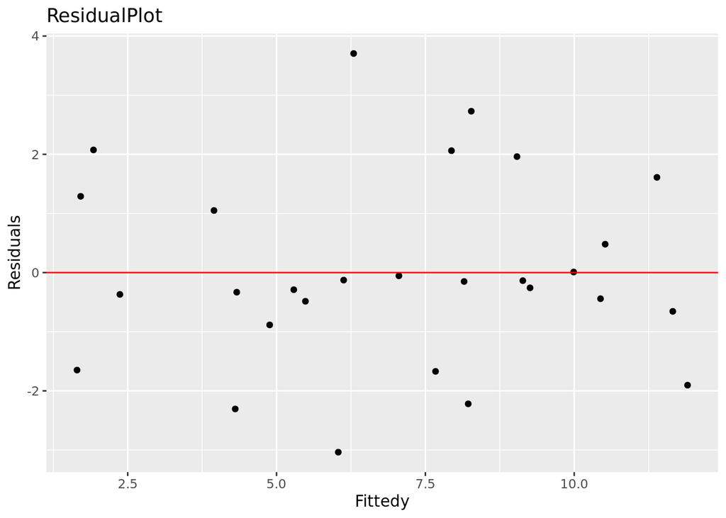

```r
f_result <- lm(y ~ x2 + x7 + x8, data = nfl)

##storefittedy&residuals
yhat<-f_result$fitted.values
res<-f_result$residuals

##addtodataframe
Data <-data.frame(nfl,yhat,res)


ggplot(Data,aes(x=yhat,y=res)) +
  geom_point()+
  geom_hline(yintercept=0,color="red")+
  labs(x="Fittedy", y="Residuals", title="ResidualPlot")
```

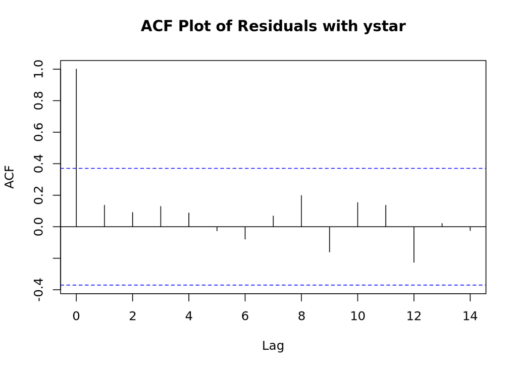

```r
acf(res, main="ACF Plot of Residuals with ystar")
```

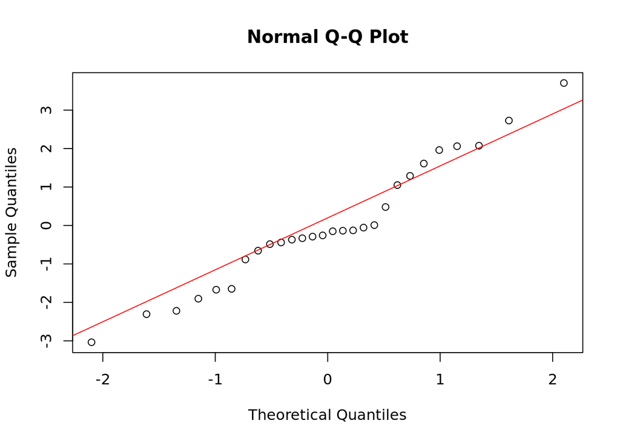

```r
qqnorm(res)
qqline(res, col="red")
```

**(g)** No. The t-test of multiple linear regression does not necessarily measure linearity. In order to assess if $x_1$ is linearly related to the response variable, we should do simple linear regression on $y$ ~ $x_1$.

```r
result2 <- lm(y~x2+x7+x8+x1, data = nfl)
summary(result2)
```

```
##
## Call:
## lm(formula = y ~ x2 + x7 + x8 + x1, data = nfl)
##
## Residuals:
##     Min      1Q  Median      3Q     Max
## -2.7456 -0.6801 -0.1941  1.1033  3.7580
##
## Coefficients:
##               Estimate Std. Error t value Pr(>|t|)
## (Intercept) -0.8791718  8.1955007  -0.107  0.91550
## x2           0.0035214  0.0007191   4.897 6.02e-05 ***
## x7           0.1437590  0.1280424   1.123  0.27313
## x8          -0.0046994  0.0013131  -3.579  0.00159 **
## x1           0.0009045  0.0016489   0.549  0.58862
## ---
## Signif. codes:  0 '***' 0.001 '**' 0.01 '*' 0.05 '.' 0.1 ' ' 1
##
## Residual standard error: 1.732 on 23 degrees of freedom
## Multiple R-squared:  0.7891, Adjusted R-squared:  0.7524
## F-statistic: 21.51 on 4 and 23 DF,  p-value: 1.702e-07
```